# Clustering Analysis for Drilling Machine States

Maximilian Knapp

May 8, 2025

```r
# Load required libraries
library(tidyverse)
library(cluster)
library(factoextra)
library(dbscan)
library(gridExtra)
```

## Introduction

This report presents a clustering analysis of operational measurements from a newly purchased drilling machine. The objective is to:

1. Determine the number of states in which the machine operates
2. Identify the state for each of the 400 observations

Since the machine lacks proper documentation (instructions are in Chinese and the producer is unresponsive), we will use unsupervised learning techniques to discover patterns in the data. We will apply three different clustering methods:

- K-means clustering
- Hierarchical clustering
- DBSCAN (Density-Based Spatial Clustering of Applications with Noise)

## Data Preparation

```r
# Load data
drill <- read.csv("drilling.csv")

# Examine the structure and first few rows
str(drill)
```

```
## 'data.frame':    400 obs. of  2 variables:
##  $ x: num  0.312 0.612 0.567 0.179 0.242 ...
##  $ y: num  0.224 0.86 0.147 0.387 0.247 ...
```

```r
head(drill)
```

```
##           x         y
## 1 0.3119099 0.2238456
## 2 0.6119440 0.8597590
## 3 0.5669062 0.1472515
## 4 0.1786455 0.3873527
## 5 0.2415186 0.2470689
## 6 0.6831982 0.8790052
```

```r
# Summary statistics
summary(drill)
```

```
##        x                  y
##  Min.   :-0.04969   Min.   :-0.05967
##  1st Qu.: 0.19177   1st Qu.: 0.18619
##  Median : 0.40684   Median : 0.40299
##  Mean   : 0.41582   Mean   : 0.45929
##  3rd Qu.: 0.65068   3rd Qu.: 0.73264
##  Max.   : 0.88515   Max.   : 1.06394
```

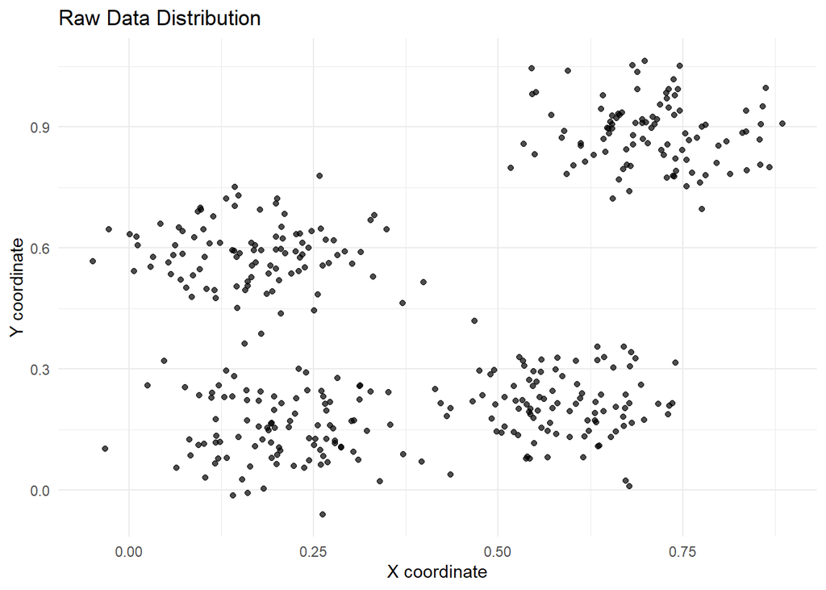

```r
# Plot the raw data
ggplot(drill, aes(x = x, y = y)) +
  geom_point(alpha = 0.7) +
  labs(title = "Raw Data Distribution",
       x = "X coordinate",
       y = "Y coordinate") +
  theme_minimal()
```

## 1. K-means Clustering

### 1.1 Finding Optimal K using Elbow Method

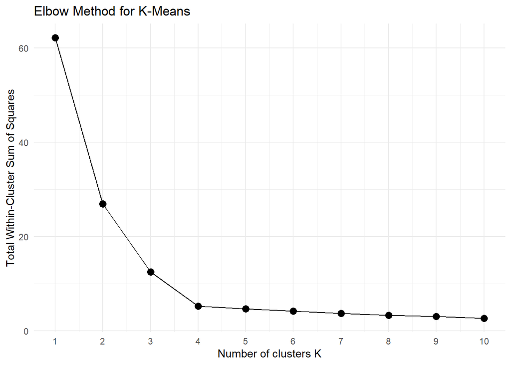

```r
# Calculate WSS for different values of K
set.seed(123)
wss <- map_dbl(1:10, ~ kmeans(drill, centers = ., nstart = 25)$tot.withinss)

# Plot the elbow curve
elbow_data <- tibble(k = 1:10, wss = wss)

ggplot(elbow_data, aes(k, wss)) +
  geom_line() +
  geom_point(size = 3) +
  labs(title = "Elbow Method for K-Means",
       x = "Number of clusters K",
       y = "Total Within-Cluster Sum of Squares") +
  theme_minimal() +
  scale_x_continuous(breaks = 1:10)
```